# Układy równań liniowych 2

### Metoda rozkładu LU

Metoda rozkładu LU dla układu równań

\begin{equation}\label{eq:url1} \mathbb{Ax}=\mathbb{b} \end{equation}

polega na przedstawieniu macierzy układu równań $\mathbb{A}$ w postaci

\begin{equation}\label{eq:dlu} \mathbb{A}=\mathbb{LU} \end{equation}

gdzie $\mathbb{L}$ jest macierzą dolnotrójkątną, a $\mathbb{U}$ gornonotrójkątną, np.

\begin{equation}\mathbb{L}=\left(\begin{matrix} l_{11} & 0 &0\\ l_{21} & l_{22} &0\\ l_{31} & l_{32} &l_{33} \end{matrix}\right) \end{equation}\begin{equation}\mathbb{U}=\left(\begin{matrix} u_{11} &u_{12} &u_{13}\\ 0 & u_{22} &u_{23}\\ 0 & 0 &u_{33} \end{matrix}\right) \end{equation}

Teraz układ równań (\ref{eq:url1}) przyjmie postać

$$\mathbb{LUx}=\mathbb{b}$$

i można go rozwiązać metodą podstawiania, zastosowaną dwukrotnie.

Najpierw obliczamy $\mathbb{y}$ z

$$\mathbb{Ly}=\mathbb{b},$$

a mając $\mathbb{y}$ obliczymy $\mathbb{x}$ z układu

$$\mathbb{Ux}=\mathbb{y}$$

Omówimy dwie metody rozkładu LU

\begin{enumerate} \item Metodę Doolitle'a. \item Rozkład Choleskiego. \end{enumerate}

#### Metoda Doolitle'a rozkładu LU

W metodzie Doolitle'a macierz $\mathbb{L}$ ma elementy diagonalne równe 1, np. dla n=3 rozkład LU jest postaci

$$\mathbb{A}=\mathbb{LU}=\left( \begin{matrix} 1 & 0 &0\\ l_{21} & 1 &0\\ l_{31} & l_{32} &1 \end{matrix}\right) \left( \begin{matrix} u_{11} &u_{12} &u_{13}\\ 0 & u_{22} &u_{23}\\ 0 & 0 &u_{33} \end{matrix}\right)$$

czyli

$$ \mathbb{A}= \left( \begin{matrix} u_{11} &u_{12} &u_{13}\\ u_{11}l_{21}&u_{12}l_{21}+u_{22}&u_{13}l_{21}+u_{23}\\ u_{11}l_{31}&u_{12}l_{31}+u_{22}l_{32}&u_{13}l_{31}+u_{23}l_{32}+u_{33} \end{matrix}\right) $$

Składowe macierzy $\mathbb{L}$ i $\mathbb{U}$ możemy łatwo obliczyć

$$ \begin{matrix} u_{11}=&a_{11}, &u_{12}=&a_{12}, &u_{13}=&a_{13}\\ l_{21}=&a_{21}/u_{11}, &u_{22}=&a_{22}-u_{12}l_{21}, &u_{23}=&a_{23}-u_{13}l_{21}\\ l_{31}=&a_{31}/u_{11}, &l_{32}=&\left(a_{32}-u_{12}l_{31}\right)/u_{22}, &u_{33}=&a_{33}-u_{13}l_{31}-u_{23}l_{32} \end{matrix} $$

Pokażemy teraz, że macierze $\mathbb{L}$ i $\mathbb{U}$ można otrzymać metodą eliminacji Gaussa

W pierwszym kroku tej metody przekształcamy wiersze macierzy

$$ \left( \begin{matrix} u_{11} &u_{12} &u_{13}\\ u_{11}l_{21}&u_{12}l_{21}+u_{22}&u_{13}l_{21}+u_{23}\\ u_{11}l_{31}&u_{12}l_{31}+u_{22}l_{32}&u_{13}l_{31}+u_{23}l_{32}+u_{33} \end{matrix}\right) $$

w następujący sposób

wiersz(2)<-- wiersz(2) - $l_{21}$ wiersz(1)

wiersz(3)<-- wiersz(3) - $l_{31}$ wiersz(1)

otrzymując

$$ \left( \begin{matrix} u_{11} &u_{12} &u_{13}\\ 0& u_{22}&u_{23}\\ 0&u_{22}l_{32}&u_{23}l_{32}+u_{33} \end{matrix}\right) $$

W drugim kroku zastępujemy trzeci wiersz

wiersz(3)<-- wiersz(3) - $l_{32}$ wiersz(2)

otrzymując ostatecznie

$$ \left( \begin{matrix} u_{11} &u_{12} &u_{13}\\ 0& u_{22}&u_{23}\\ 0& 0& u_{33} \end{matrix}\right) $$

Tym samym wykazaliśmy, że

\begin{enumerate} \item Macierz $\mathbb{U}$ jest taka sama jak macierz górnotrójkątna z eliminacji Gaussa. \item Pozadiagonalne elementy macierzy $\mathbb{L}$ są mnożnikami użytymi metodzie eliminacji Gaussa. \end{enumerate}

Przykład

\begin{equation} \mathbb{A}=\left(\begin{matrix} 8 &-6 &2 \\ -4 & 11 &-7 \\ 4 &- 7 &6 \end{matrix}\right) \end{equation}

Pierwszy krok eliminacji Gaussa

wiersz(2)<-- wiersz(2) - $(-4/8)$ wiersz(1) => $l_{21}=-1/2$

wiersz(3)<-- wiersz(3) - $4/8$ wiersz(1) => $l_{31}=1/2$

prowadzi do macierzy

\begin{equation} \left(\begin{matrix} 8 &-6 &2 \\ 0 & 8 &-6 \\ 0 &-4 &5 \end{matrix}\right) \end{equation}

I jeszcze transormacja trzeciego wiersza

wiersz(3)<-- wiersz(3) - $(-4/8)$ wiersz(1) => $l_{32}=-1/2$

prowadzi do macierzy górnotrójkątnej

\begin{equation} \left(\begin{matrix} 8 &-6 &2 \\ 0 & 8 &-6 \\ 0 &0 &2 \end{matrix}\right) \end{equation}

W ten sposób dostaliśmy rozkład LU z $$\mathbb{L}=\left( \begin{matrix} 1 & 0 &0\\ -1/2 & 1 &0\\ 1/2 &-1/2 &1 \end{matrix}\right) $$ i $$\mathbb{U}=\left( \begin{matrix} 8 &-6 &2 \\ 0 & 8 &-6 \\ 0 &0 &2 \end{matrix}\right) $$

```python
# Sprawdźmy teraz ten rozkład obliczając L i U
import numpy as np
L=np.array([[1,0,0],[-1/2,1, 0],[1/2,-1/2, 1]])

U=np.array([[8,-6,2],[0,8, -6],[0,0, 2]])

A=np.array([[8,-6,2],[-4,11, -7],[4,-7, 6]])
print(np.dot(L,U))
print('\n',A-np.dot(L,U))
```

```
[[ 8. -6.  2.]
 [-4. 11. -7.]
 [ 4. -7.  6.]]

 [[0. 0. 0.]
 [0. 0. 0.]
 [0. 0. 0.]]
```

A teraz wykorzystamy metodę rozkładu LU z modulu scipy https://docs.scipy.org/doc/scipy/reference/generated/scipy.linalg.lu.html#scipy.linalg.lu

```python
from scipy import linalg
P1,L1,U1=linalg.lu(A)
print(L1)
print('\n',U1)
print('\n',P1)
```

```
[[ 1.   0.   0. ]
 [-0.5  1.   0. ]
 [ 0.5 -0.5  1. ]]

 [[ 8. -6.  2.]
 [ 0.  8. -6.]
 [ 0.  0.  2.]]

 [[1. 0. 0.]
 [0. 1. 0.]
 [0. 0. 1.]]
```

Użycie rozkładu LU jest korzystne gdy rozwiązujemy wiele układów równań z tą samą macierzą A, np. macierz odwrotną można otrzymać z rowzwiązań układów równań liniowych typu

\begin{equation}\label{eq:urmo} \mathbb{Ax^{(i)}}=\mathbb{e_i}\;\;\;i=1,\ldots n \end{equation}

gdzie $\mathbb{e_i}$ jest wektorem jednostkowym mającym jedynkę na i-tym miejscu i zera na pozostałych pozycjach, a wektory $\mathbb{x^{(i)}}$ są kolumnami macierzy odwrotnej $\mathbb{A^{-1}}$.

Wykonując jeden raz rozkład LU efektywnie rozwiążemy n układów równań (\ref{eq:urmo}) otrzymując $\mathbb{A^{-1}}$.

#### Rozkład Choleskiego

Dla macierzy A symetrycznej i dodatnio określonej istnieje rozkład

\begin{equation}\label{eq:chlu1} \mathbb{A}=\mathbb{LL^T} \end{equation}

gdzie dla $n=3$

\begin{equation}\label{eq:chlu2} \mathbb{LL^T}=\left(\begin{matrix} l_{11} & 0 &0\\ l_{21} & l_{22} &0\\ l_{31} & l_{32} &l_{33} \end{matrix}\right) \left(\begin{matrix} l_{11} &l_{21} &l_{31}\\ 0 & l_{22} &l_{32}\\ 0 & 0 &l_{33} \end{matrix}\right) \end{equation}

Wstawiając (\ref{eq:chlu2}) do (\ref{eq:chlu1}) dostaniemy układ równań nieliniowych na składowe macierzy $\mathbb{L}$

\begin{equation}\label{eq:chlu3} \left(\begin{matrix} l_{11}^2 & l_{11}l_{21} &l_{11}l_{31}\\ l_{11}l_{21} & l_{21}^2+l_{22}^2 &l_{21}l_{31}+l_{22}l_{32}\\ l_{11}l_{31} &l_{21}l_{31}+l_{22}l_{32} &l_{31}^2+l_{32}^2+l_{33}^2 \end{matrix}\right) = \left(\begin{matrix} a_{11} & a_{21} & a_{31}\\ a_{21} & a_{22} & a_{32}\\ a_{31} & a_{32} & a_{33} \end{matrix}\right) \end{equation}

Z postaci tego układu, że znalezienie rozwiązania jest łatwym zadaniem

$$l_{11}=\sqrt{a_{11}}$$$$l_{21}=a_{21}/l_{11}$$$$l_{31}=a_{31}/l_{11}$$$$l_{22}=\sqrt{a_{22}-l_{21}^2}$$$$l_{32}=\left(a_{32}-l_{21}l_{31}\right)/l_{22}$$$$l_{33}=\sqrt{a_{33}-l_{31}^2-l_{32}^2}$$

W tej metodzie wykonujemy o połowę mniej operacji niż w rozkładzie LU Doolitle'a

Przykład zastosowania rozkładu Choleskiego z modułu scipy dla macierzy trójdiagonalnej

\begin{equation} \mathbb{T}=\left(\begin{matrix} 4 &2 &0 &0 \\ 2 &4 &2 &0\\ 0 &2 &4 &2\\ 0 &0 &2 &4 \end{matrix}\right) \end{equation}

```python
# T macierz trójdiagonalna
T=np.array([[4,2,0,0],[2,4,2,0],[0,2,4, 2],[0,0,2,4]])
print(T)
L1=linalg.cholesky(T,lower=True)
np.set_printoptions(precision=3)
print('\n',L1)
#macierz transponowana
print('\n',L1.T)
#iloczyn L1 i jej transpowanej
print('\n',np.dot(L1,L1.T))
```

```
[[4 2 0 0]
 [2 4 2 0]
 [0 2 4 2]
 [0 0 2 4]]

 [[2.    0.    0.    0.   ]
 [1.    1.732 0.    0.   ]
 [0.    1.155 1.633 0.   ]
 [0.    0.    1.225 1.581]]

 [[2.    1.    0.    0.   ]
 [0.    1.732 1.155 0.   ]
 [0.    0.    1.633 1.225]
 [0.    0.    0.    1.581]]

 [[4. 2. 0. 0.]
 [2. 4. 2. 0.]
 [0. 2. 4. 2.]
 [0. 0. 2. 4.]]
```

Widzimy, że dekompozycja Choleskiego macierzy pasmowej prowadzi do pasmowej  
macierzy L - ma elementy różne od zera tylko na dwóch przekątnych.

Dla porównania obliczymy jeszcze rozkład LU tej trójdiagonalnej macierzy

```python
# Jak wygląda rozkład LU macierzy TD?
P2,L2,U2=linalg.lu(T)
print(L2)
print('\n',U2)
print('\n',np.dot(L2,U2))
```

```
[[1.    0.    0.    0.   ]
 [0.5   1.    0.    0.   ]
 [0.    0.667 1.    0.   ]
 [0.    0.    0.75  1.   ]]

 [[4.    2.    0.    0.   ]
 [0.    3.    2.    0.   ]
 [0.    0.    2.667 2.   ]
 [0.    0.    0.    2.5  ]]

 [[4. 2. 0. 0.]
 [2. 4. 2. 0.]
 [0. 2. 4. 2.]
 [0. 0. 2. 4.]]
```

### Częściowy wybór elementu podstawowego w eliminacji Gaussa

Do poniższego układu równań

\begin{equation} \begin{array}{ccc} & &2x_2 & + &2x_3 &=& 1\\ 3x_1 &+ & 3x_2& & &=& 3\\ x_1 & & &+&x_3 &=& 2 \end{array} \end{equation}

nie możemy bezpośrednio zastosować eliminacji Gaussa ponieważ pierwszy element podstawowy $a_{11}=0$.

Wyjściem z tej sytuacji jest zmiana kolejności równań 1 i 2 w tym układzie

Ogólnie, dla układu

$$ \mathbb{Ax}=\mathbb{b} $$

możemy zastsować częściowy wybór elementu podstawowego w eliminacji Gaussa polegający na tym, że w k-tym kroku tej metody zamieniamy wiersze r i k tej macierzy, gdzie numer wiersza r jest wyznaczany z warunku

$$ \left|a_{rk}^{(k)}\right|=\max_{k\leq i \leq n}\left|a_{ik}^{(k)}\right| $$

Pokażemy teraz działanie tej metody na naszym przykładzie, dla którego

$$\mathbb{A}=\left( \begin{matrix} 0 & 2 & 2\\ 3 & 3 & 0 \\ 1 & 0 & 1 \end{matrix}\right) $$

W pierszym kroku metody eliminacji Gaussa z częsciowym wyborem elementu podstawowego, k=1, szukamy wiersza r, w którym moduł składowej z pierwszej kolumny ma największą wartość. Łatwo znajdujemy, że r=2. Po zamianie wierszy 1 i 2 otrzymujemy $\mathbb{A} $ w postaci

$$\left( \begin{matrix} 3 & 3 & 0 \\ 0 & 2 & 2\\ 1 & 0 & 1 \end{matrix}\right) $$

Teraz eliminujemy tylko składową $a_{31}$ (bo $a_{21}=0$) za pomocą przekształcenia

wiersz(3)<-- wiersz(3) - 1/3 wiersz(1)

Otrzymując

$$ \left( \begin{matrix} 3 & 3 & 0 \\ 0 & 2 & 2\\ 0 & -1 & 1 \end{matrix}\right) $$

W drugim kroku tej metody, k=2, widzimy, że spośród składowych $a_{22}$ i $a_{32}$ większą bezwględną wartość ma ta pierwsza, więc r=k=2. Tym samym nie musimy przestawiać wierszy macierzy i możemy wyeliminować składową $a_{32}$ za pomocą przekształcenia

wiersz(3)<-- wiersz(3) + 1/2 wiersz(2)

W wyniki tej operacji otrzymujemy macierz górnotrójkątną

$$ \left( \begin{matrix} 3 & 3 & 0 \\ 0 & 2 & 2\\ 0 & 0 & 2 \end{matrix}\right) $$

W metodzie tej używa się jeszcze jednej macierzy permutacji $\mathbb{P}$ do zamiany wierszy. W tym przykładzie

$$\mathbb{P}=\left( \begin{matrix} 0 & 1 & 0\\ 1 & 0 & 0 \\ 0 & 0 & 1 \end{matrix}\right) $$

i łatwo sprawdzić, że iloczyn $\mathbb{PA}$ zamienia wiersze 1 i 2 w macierzy $\mathbb{A}$

```python
#Teraz wykorzystamy scipy do rozkładu LU macierzy A z przykładu
A3=np.array([[0,2,2],[3,3,0],[1,0,1]])
P3,L3,U3=linalg.lu(A3)
print(L3)
print('\n',U3)
print('\n',P3)
```

```
[[ 1.     0.     0.   ]
 [ 0.     1.     0.   ]
 [ 0.333 -0.5    1.   ]]

 [[3. 3. 0.]
 [0. 2. 2.]
 [0. 0. 2.]]

 [[0. 1. 0.]
 [1. 0. 0.]
 [0. 0. 1.]]
```

```python
Oprócz macierzy L i U, funkcja linalg.lu zwraca też macierz permutacji P.
```

### Macierze źle uwarunkowane

Pokażemy teraz jakie problemy pojawiają się gdy macierz układu równań liniowych jest źle uwarunkowana.

Układ n równań liniowych

\begin{equation}\label{eq:urh} \mathbb{Hx}=\mathbb{b} \end{equation}

z macierzą Hilberta

\begin{equation}\label{eq:mh} H_{ij}=\frac{1}{i+j+1}, \;\;\;i,j=0,1,\ldots,n-1 \end{equation}

i wektorem $\mathbb{b}$ o składowych $b_i=\sum_j{H_{ij}}$ ma łatwe do znalezienia rozwiązanie

$$x_i=1, \;\;\;i=0,1,\ldots,n-1 $$

Sprawdzimy teraz wskaźnik uwarunkowania macierzy Hilberta dla $1<n\le 16$.

```python
from numpy import linalg as la

for j in range (2,17):
    print ("%3d   %e"%(j,la.cond(linalg.hilbert(j),np.inf)))
```

```
  2   2.700000e+01
  3   7.480000e+02
  4   2.837500e+04
  5   9.436560e+05
  6   2.907028e+07
  7   9.851949e+08
  8   3.387279e+10
  9   1.099652e+12
 10   3.535685e+13
 11   1.234533e+15
 12   4.255399e+16
 13   7.781658e+17
 14   1.148964e+18
 15   1.041727e+18
 16   1.008337e+19
```

Ponieważ macierz (\ref{eq:mh}) jest źle uwarunkowana to zbadamy jak ten fakt wpływa na numeryczne rozwiązania układu (\ref{eq:urh}) otrzymane za pomocą linalg.solve()

```python
# Sprawdzimy rozwiązania  dla  n=4,8 i 16
n=4
while n<17:
    H=linalg.hilbert(n)
    b=np.zeros(n)
    for i in range(n):
        b[i]=np.sum(H[i])
    x=linalg.solve(H,b)
    print('\nn=',n,' x=',x)
    n=2*n
```

```
n= 4  x= [1. 1. 1. 1.]

n= 8  x= [1. 1. 1. 1. 1. 1. 1. 1.]

n= 16  x= [  1.      1.      0.999   1.016   0.864   1.671  -0.88    3.518   1.611
  -6.066   8.494   5.79  -17.55   19.619  -7.718   2.631]
```

```python
Powyższy przykład pokazuję, że dla $n=16$ otrzymaliśmy błędne rozwiązanie!
Czy istnieją inne metody rozwiązujące poprawnie taki układ równań?
Tak. Odpowiedź w następnym punkcie.
```

### Metody iteracyjne rozwiązywania układów równań

Układ równań $$ \mathbb{Ax}=\mathbb{b} $$ można rozwiazać iteracyjne startując z początkowego (odgadniętego) rozwiązania $\mathbb{x^{(0)}}$.

Macierz układu można zapisić jako sumę trzech macierzy $$\mathbb{A}=\mathbb{D}+\mathbb{L}+\mathbb{U} $$ gdzie $\mathbb{D}$ zawiera tylko składowe diagonalne z $\mathbb{A}$, $\mathbb{L}$ ma składowe leżące poniżej diagonali w $\mathbb{A}$ i
$\mathbb{U}$ zawiera składowe z $\mathbb{A}$ powyżej diagonali.

Przykład. Dla macierzy

\begin{equation} \mathbb{A}=\left(\begin{matrix} 8 &-6 &2 \\ -4 & 11 &-7 \\ 4 &- 7 &6 \end{matrix}\right) \end{equation}

otrzymujemy te trzy macierze w postaci

\begin{equation} \mathbb{D}=\left(\begin{matrix} 8 & 0 &0 \\ 0 & 11 &0 \\ 0 &0 &6 \end{matrix}\right), \mathbb{L}=\left(\begin{matrix} 0 & 0 &0 \\ -4 & 0 &0 \\ 4 & -7 &0 \end{matrix}\right), \mathbb{U}=\left(\begin{matrix} 0&-6 &2 \\ 0 & 0 &-7 \\ 0 &0 &0 \end{matrix}\right) \end{equation}

#### Metoda Jacobiego

Wektor $\mathbb{x^{(k+1)}}$ w k+1 kroku oblicza się z jego wartości w poprzednim kroku $\mathbb{x^{(k)}}$ za pomocą następującego schematu iteracyjnego

$$\mathbb{Dx^{(k+1)}}=-\left(\mathbb{L}+\mathbb{U}\right) \mathbb{x^{(k)}}+\mathbb{b}$$

Stąd dostajemy wyrażenie na składowe wektora $\mathbb{x^{(k+1)}}$

$$ x_i^{(k+1)}=\frac{-\sum_{j\neq i}^n{a_{ij}x_j^{(k)}}+b_i}{a_{ii}} $$

#### Metoda Gaussa-Seidla

W tej metodzie schemat iteracyjny ma postać

$$\mathbb{Dx^{(k+1)}}=-\mathbb{Lx^{(k+1)}}+\mathbb{Ux^{(k)}} +\mathbb{b}$$

a składowe $\mathbb{x^{(k+1)}}$ otrzymujemy z

$$ x_i^{(k+1)} =\frac{-\sum_{j=0}^{i-1}{a_{ij}x_j^{(k+1)}}-\sum_{j=i+1}^{n}{a_{ij}x_j^{(k)}}+b_i}{a_{ii}} $$

```python
# Rozwiążemy teraz metodą Gaussa-Seidela układ równań z macierzą Hilberta dla n=16
n=16
print('\nn=',n)
H=linalg.hilbert(n)

# wektor b
b=np.zeros(n)
for i in range(n):
    b[i]=np.sum(H[i])

# X0
x=np.zeros(n)
x[0]=2

# iteracyjne obliczanie wektora x

for t in range(1,10001):
    #obliczanie składowych x w kroku t
    for i in range(n):
        sm=0.0
        for j in range(n):
            if(j == i):
                continue
            sm=sm+x[j]*H[i,j]
        x[i]=(-sm+b[i])/H[i,i]
    if t%1000 ==0:
# obliczanie odchylenia od dokładnego rozwiązania
        dx=np.sqrt( np.sum((x-1)**2))
        print(t,' ',dx)
# roziązanie po 10000 iteracji
print('\nx=',x)
```

```
n= 16
1000   0.17154780729399063
2000   0.12247679753452759
3000   0.0870608071804577
4000   0.06694375614671907
5000   0.057369462524286804
6000   0.05379757537538748
7000   0.05286744686175675
8000   0.052758808796182
9000   0.05270498803594618
10000   0.05245470744254104

x= [1.    1.004 0.979 1.027 1.01  0.99  0.983 0.987 0.996 1.005 1.011 1.014
 1.012 1.005 0.995 0.981]
```

Pokazaliśmy, że metoda Gaussa-Seidla dla źle uwarunkowanej macierzy prowadzi do prawidłowego rozwiązania, chociaż w tym przypadku metoda iteracyjna jest wolnozbieżna. Przypomnijmy, że metody bezpośrednie (np. eleminacja Gaussa) nie dają poprawnego rozwiązania dla tego układu równań.

#### Metody iteracyjne w Scipy

Kilka metod iteracyjnych można znaleźć w scipy.sparse.linalg. Zastosujemy metodę gradientów sprzężonych https://docs.scipy.org/doc/scipy/reference/generated/scipy.sparse.linalg.cg.html#scipy.sparse.linalg.cg

do rozwiązania układu (\ref{eq:urh})

```python
# Metoda gradientów sprzęzonych z scipy.sparse.linalg
# dla macierzy symetrycznej, dodatnio określonej

from scipy.sparse.linalg import cg
n=32
H=linalg.hilbert(n)
# wektor b
b=np.zeros(n)
for i in range(n):
    b[i]=np.sum(H[i])
#początkowa wartość x
x0=np.zeros(n)
x0[0]=2
#3 rozwiązania z różną dokłądność tol
x,inf=cg(H,b,x0,tol=1e-4,atol=1e-4)
np.set_printoptions(precision=5)
print(' x=',x)
x,inf=cg(H,b,x0,tol=1e-8,atol=1e-8)
print('\n x=',x)
x,inf=cg(H,b,x0,tol=1e-15,atol=1e-8)
print('\n x=',x)
```

```
 x= [1.00134 0.97262 1.06245 1.01582 0.98091 0.96613 0.96474 0.97065 0.97986
 0.99    0.99972 1.00829 1.01539 1.0209  1.02481 1.02722 1.02822 1.02797
 1.02657 1.02418 1.02089 1.01684 1.01211 1.00679 1.00098 0.99474 0.98814
 0.98123 0.97407 0.96669 0.95915 0.95147]

 x= [1.00006 0.99868 1.00602 0.99352 0.99651 1.00126 1.00363 1.00371 1.00247
 1.0008  0.99923 0.99804 0.99734 0.99712 0.9973  0.99779 0.99849 0.99931
 1.00015 1.00095 1.00165 1.0022  1.00257 1.00272 1.00265 1.00233 1.00176
 1.00094 0.99988 0.99856 0.99701 0.99523]

 x= [1.      0.99997 1.00026 0.99928 1.00052 1.0004  0.99991 0.99965 0.99968
 0.99986 1.00006 1.0002  1.00026 1.00023 1.00016 1.00006 0.99995 0.99987
 0.99981 0.99979 0.99981 0.99986 0.99992 1.      1.00008 1.00015 1.00019
 1.0002  1.00017 1.00007 0.99992 0.99969]
```

```python
Widzimy, że metoda gradientów sprzężonych znajduje rozwiązanie bliskie dokładnego
```

### Duże układy równań - macierze rzadkie

Duże układy równań liniowych pojawiają się np. w rozwiązywaniu równań różniczkowych metodą różnic skończonych. Metodę tę poznamy później, a teraz zbadamy rozwiązanie układu równań dla równania różniczkowego

\begin{equation} \label{eq:mrs7} \frac{d^2y}{dx^2}=-y-2y^{\prime} \end{equation}

z warunkami brzegowymi $y(0)=0, \;\;y(1)=1$.

Wprowadzając dyskretne wartości x i y $$x_i=ih,\;\;h=1/n,\;\;i=0,1,\ldots,n$$ $$y_i=y(x_i)$$ możemy zastąpić równanie różniczkowe (\ref{eq:mrs7}) następującym układem równań liniowych

$$\mathbb{A}\mathbb{y}=\mathbb{u}$$

z

$\mathbb{y}=\left(y_1,y_2,\ldots,y_{n-2},y_{n-1}\right)^T$,

$\mathbb{u}=\left(0,0,\ldots,0,-h-1\right)^T$

i trójdiagonalną macierzą

\begin{equation} \mathbb{A}=\left(\begin{matrix} d & e_2 & 0 & 0 &0 & \cdots & 0\\ e_1 & d & e_2 & 0 &0 & \cdots & 0\\ 0 & e_1 & d & e_2 &0 & \cdots & 0\\ & & \ddots& \ddots& \ddots & & \\ 0 & \cdots &0 & e_1 & d & e_2& 0\\ 0 & \cdots & 0 &0 & e_1 & d & e_2\\ 0 & \cdots & 0 &0 & 0 & e_1 & d \end{matrix}\right) \end{equation}

gdzie $$ d=h^2-2,\;\;\;e_1=1-h,\;\;e_2=1+h $$

Ponieważ $\mathbb{A}$ jest macierzą rzadką dla dużych n, to rozwiążemy ten układ metodą spsolve z  
scipy.sparse.linalg dla $n=10^6$

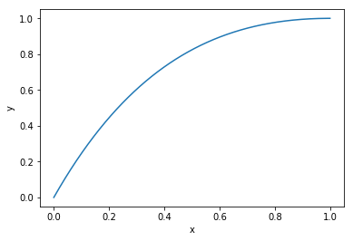

```python
import numpy as np
%matplotlib  inline
import matplotlib.pyplot as plt
# wykorzystamy macierze i układy rzadkie
from scipy.sparse import diags
from scipy.sparse.linalg  import spsolve

# rozmiar macierzy n*n
n=1000000

# krok dyskretyzacji
h=1.0/n

# tablica elementów na diagonali
d=(h**2-2)*np.ones(n-1)

# tablica elementów pod diagonalą
e1=(1-h)*np.ones(n-2)

# tablica elementów nad diagonalą
e2=(1+h)*np.ones(n-2)

#lista niezerowych elementów macierzy rzadkiej
data=[d.tolist(),e2.tolist(),e1.tolist()]

#offsets
# k = 0 the main diagonal (default)
# k > 0 the k-th upper diagonal
# k < 0 the k-th lower diagonal
positions=[0,1,-1]

# trójdiagonalna macierz
A=diags(data,positions,(n-1,n-1))

# przekształcenie macierzy  A do CSR - compressed sparse  row format
A =A.tocsr()

# wektor stały u
uu=np.zeros(n-1)
uu[n-2]=-h-1

# rozwiązanie układu równań liniowych Ay=u
y = spsolve(A, uu)

# wykres rozwiazania y(x)
x=np.arange(h,1,h)
plt.plot(x, y)
plt.xlabel('x')
plt.ylabel('y')
plt.show()
```